# California Renewables Data

ER131: Data, Envinronment and Society.

In this notebook, we'll do a brief tour of the data set we'll be working with from the California Independent System Operator.

You'll also get a glimpse of what the functions in the `pandas` library can do; we'll spend more time learning `pandas` in the next week.

First let's load in csv, pandas and numpy:

```python
import numpy as np # numpy is something like a matlab replacement for python.  Numeric and scientific computing.
import pandas as pd # we'll learn more about this soon
```

### Background

California ISO is the system operator for the California grid. They tell generators when and how much to produce.

They record renewable production data [here](http://content.caiso.com/green/renewrpt/)

That page links to files giving production for the *day* in question.

### Data Provenance

What can be said about the data provenance?

- Collected with power meters on all generators connected to the grid
- How were the data manipulated?
  - Aggregated by hour and generator type
- What mechanism generated the data: experiment, industrial process, observations in nature?
  - Industrial process
- Is it a random sample, a census?
  - We have access to all recorded days, but not all days in the history of the world are recorded. Administrative database.

### Let's dig in

```python
caiso_dat = pd.read_csv('August_2017_Data.csv')
```

Now we can print the result in a "dataframe". This is like a spreadsheet.

```python
caiso_dat
```

|  | Unnamed: 0 | Hour | GEOTHERMAL | BIOMASS | BIOGAS | SMALL HYDRO | WIND TOTAL | SOLAR PV | SOLAR THERMAL |
| --- | --- | --- | --- | --- | --- | --- | --- | --- | --- |
| 0 | 2017-08-01 | 1 | 959 | 197 | 180 | 362 | 3076 | 0 | 0 |
| 1 | 2017-08-01 | 2 | 959 | 194 | 180 | 350 | 3124 | 0 | 0 |
| 2 | 2017-08-01 | 3 | 960 | 196 | 180 | 361 | 3079 | 0 | 0 |
| 3 | 2017-08-01 | 4 | 961 | 197 | 179 | 353 | 2985 | 0 | 0 |
| 4 | 2017-08-01 | 5 | 959 | 199 | 180 | 349 | 2440 | 0 | 0 |
| ... | ... | ... | ... | ... | ... | ... | ... | ... | ... |
| 739 | 2017-08-31 | 20 | 1145 | 383 | 163 | 564 | 991 | 26 | 0 |
| 740 | 2017-08-31 | 21 | 1173 | 378 | 165 | 493 | 637 | 0 | 0 |
| 741 | 2017-08-31 | 22 | 1178 | 363 | 164 | 453 | 526 | 0 | 0 |
| 742 | 2017-08-31 | 23 | 1183 | 351 | 163 | 384 | 457 | 0 | 0 |
| 743 | 2017-08-31 | 24 | 1187 | 343 | 162 | 380 | 678 | 0 | 0 |

744 rows × 9 columns

Now let's look at an individual data column (more on pandas next time). Let's look at the 'SOLAR PV' data:

```python
caiso_dat['SOLAR PV']
```

```
0       0
1       0
2       0
3       0
4       0
       ..
739    26
740     0
741     0
742     0
743     0
Name: SOLAR PV, Length: 744, dtype: int64
```

To help us plot things we're going to import a new library called `matplotlib.pyplot`. We'll introduce this more formally in a few lectures.

import matplotlib.pyplot as plt

```python
import matplotlib.pyplot as plt
```

Let's plot the solar generation data using `plt.plot`

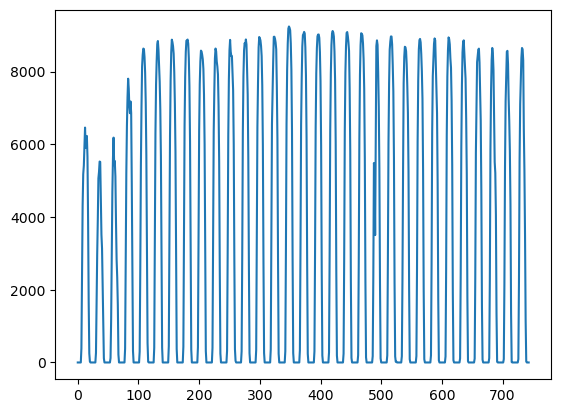

```python
plt.plot(caiso_dat['SOLAR PV'])
```

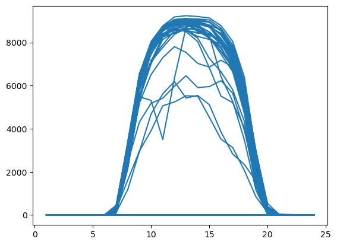

```python
# alternatively we can plot by hour of day to see things overlap
plt.plot(caiso_dat['Hour'],caiso_dat['SOLAR PV'])
```

## Some things we saw in today's notebooks

- Pandas helps us view and access 'dataframes', which are like spreadsheets of all sorts of different data.
  - We're going to learn a lot more about pandas soon
  - Some of the most-used pandas objects and methods are `.loc` and the "index"
- It's important to write functions to get your work done --
  - this makes code more readable,
  - helps for debugging
  - makes it easier to make a worksheet do many things over and over.